# chapter3

Xindi Huang

2023-11-20

```r
date()
```

```
## [1] "Mon Nov 20 17:14:58 2023"
```

```r
# laod packages
library(tidyverse)
```

```r
library(dplyr)
library(ggplot2)
library(readr)
library(boot)
```

## Read alc dataset

```r
# set working directory
setwd("~/r/IODS/IODS-project/")

# read the joined student alcohol consumption data into R
alc <- read_csv("~/r/IODS/IODS-project/data/alc.csv",show_col_types=FALSE)

# print out the names of the variables
colnames(alc)
```

```
##  [1] "school"     "sex"        "age"        "address"    "famsize"
##  [6] "Pstatus"    "Medu"       "Fedu"       "Mjob"       "Fjob"
## [11] "reason"     "guardian"   "traveltime" "studytime"  "schoolsup"
## [16] "famsup"     "activities" "nursery"    "higher"     "internet"
## [21] "romantic"   "famrel"     "freetime"   "goout"      "Dalc"
## [26] "Walc"       "health"     "failures"   "paid"       "absences"
## [31] "G1"         "G2"         "G3"         "alc_use"    "high_use"
```

**Dataset information**:

This dataset covers student achievement in secondary education for two Portuguese schools. Attributes include student grades `G1`, `G2`, `G3`, demographic factors `age`, `sex`, social features `family size`, `parental education`, etc., and school-related information `study time`,`support services`. Two distinct datasets are available for different subjects: Mathematics `mat` and Portuguese language `por`. `alc_use` is generated by averaging weekday and weekend alcohol consumption, and `high_use`, which is true if `alc_use` is greater than 2 and false otherwise.

## Hypothesis of relationships between high/low alcohol consumption and some of the other variables in the data.

Here, I choose `studytime`, `health`, `age`, `failures` four variables, and my hypothesis are:

- *Hypothesis 1*: Students who spend more time studying (`studytime`) are likely to have lower alcohol consumption.
- *Hypothesis 2*: Students with better health status (`health`) may have lower alcohol consumption.
- *Hypothesis 3*: Older students tend to have higher alcohol consumption.
- *Hypothesis 4*: Students with a higher number of past class failures (`failures`) may have higher alcohol consumption.

## Numerically and graphically exploretion

**1. Study Time** (`studytime`):

```r
# 1. Study Time vs. Alcohol Consumption

alc %>%
  group_by(high_use) %>%
  summarise(count = n(),
            mean_studytime = mean(studytime))
```

```
## # A tibble: 2 × 3
##   high_use count mean_studytime
##   <lgl>    <int>          <dbl>
## 1 FALSE      259           2.16
## 2 TRUE       111           1.77
```

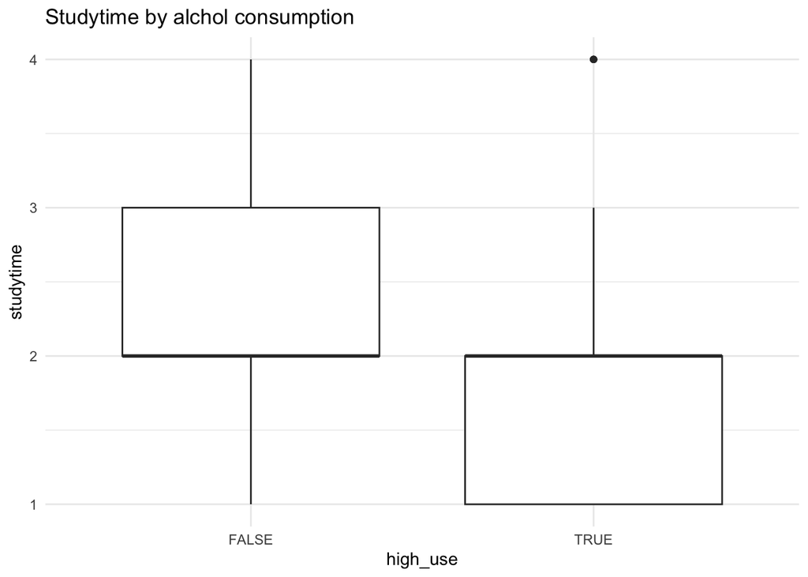

```r
ggplot(alc, aes(x = high_use, y = studytime)) +
  geom_boxplot() +
  ylab("studytime") +
  ggtitle("Studytime by alchol consumption") +
  theme_minimal()
```

- For students with high alcohol consumption, the average study time is lower, with a mean of 1.77. This suggests that, on average, students in this group spend less time studying. In contrast, for students with low alcohol consumption, the average study time is higher, with a mean of 2.16. This indicates that, on average, students in this group spend more time studying.
- The boxplot for `studytime` provides evidence that students with low alcohol consumption tend to spend more time studying compared to students with high alcohol consumption. This observation is consistent with the hypothesis that higher study time is associated with lower alcohol consumption.

**2. Health Status** (`health`):

```r
# 2. Health Status vs. Alcohol Consumption
alc %>%
  group_by(high_use) %>%
  summarise(count = n(),
            mean_health = mean(health))
```

```
## # A tibble: 2 × 3
##   high_use count mean_health
##   <lgl>    <int>       <dbl>
## 1 FALSE      259        3.49
## 2 TRUE       111        3.73
```

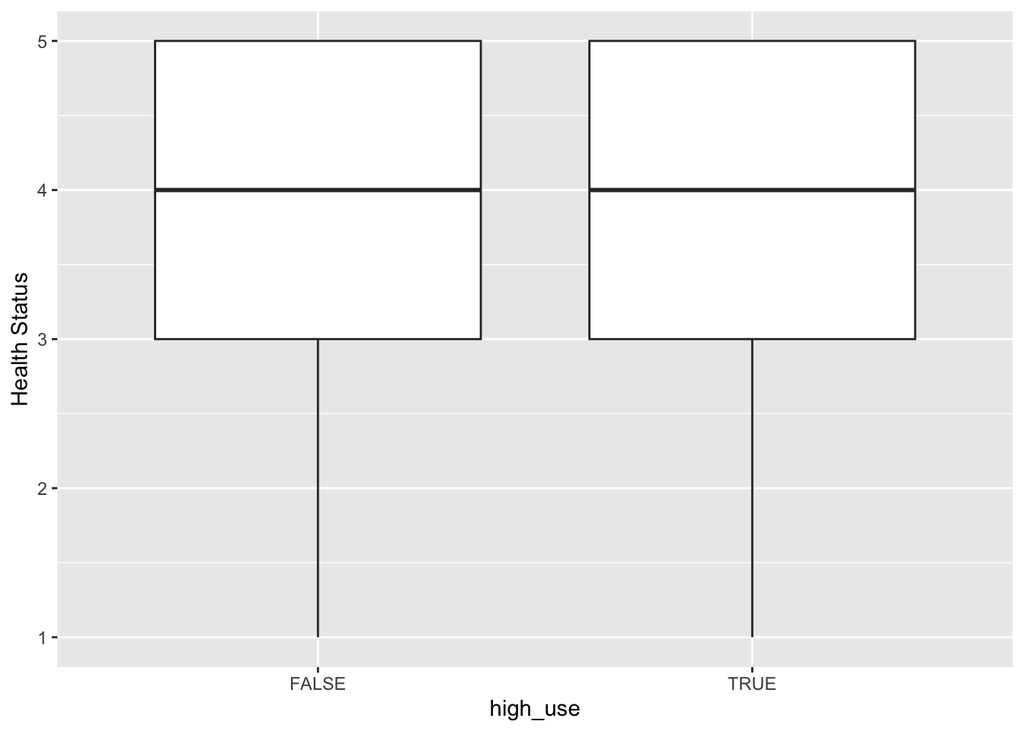

```r
ggplot(alc, aes(x = high_use, y = health)) +
  geom_boxplot() +
  ylab("Health Status")
```

```r
  ggtitle("Health Status by Alchol consumption") +
  theme_minimal()
```

- Interetsingly, the distribution of health status suggests a subtle difference between students with high and low alcohol consumption. Students with high alcohol consumption tend to report a slightly higher average health status compared to those with low alcohol consumption.
- The boxplot for `health` does not show a substantial difference between the health statuses of students with high alcohol consumption and low alcohol consumption . This observation does not strongly support the hypothesis that students with better health status are associated with lower alcohol consumption in this dataset.

**3. Age** (`age`):

```r
# 3. Age vs. Alcohol Consumption
alc %>%
  group_by(high_use) %>%
  summarise(count = n(),
            mean_age = mean(age))
```

```
## # A tibble: 2 × 3
##   high_use count mean_age
##   <lgl>    <int>    <dbl>
## 1 FALSE      259     16.5
## 2 TRUE       111     16.8
```

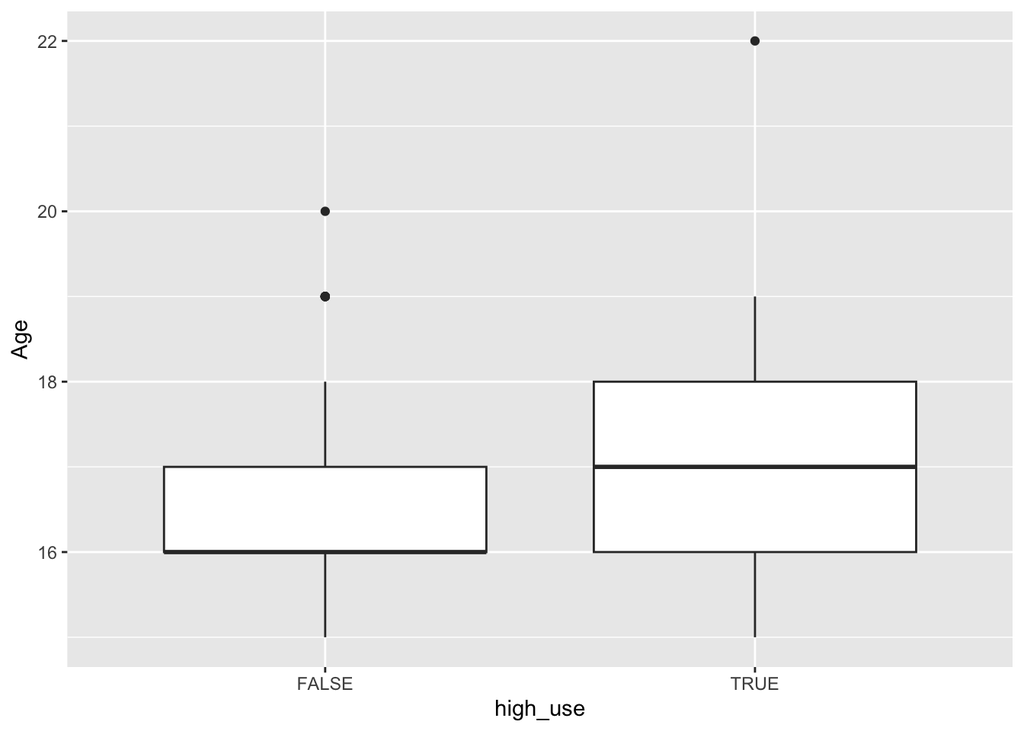

```r
ggplot(alc, aes(x = high_use, y = age)) +
  geom_boxplot() +
  ylab("Age")
```

```r
  ggtitle("Age by Alchol consumption") +
  theme_minimal()
```

- The distribution of age suggests a small difference between students with high and low alcohol consumption. Students with high alcohol consumption tend to be slightly older on average compared to those with low alcohol consumption.
- The boxplot for `age` provides evidence that younger students tend to have lower alchol consumption. This observation is consistent with the hypothesis that older students tend to have higher alcohol consumption.

**4. Number of past class failures** (`failures`):

```r
# 4. Number of past class failures vs. Alcohol Consumption
alc %>%
  group_by(high_use) %>%
  summarise(count = n(),
            mean_failures = mean(failures))
```

```
## # A tibble: 2 × 3
##   high_use count mean_failures
##   <lgl>    <int>         <dbl>
## 1 FALSE      259         0.120
## 2 TRUE       111         0.351
```

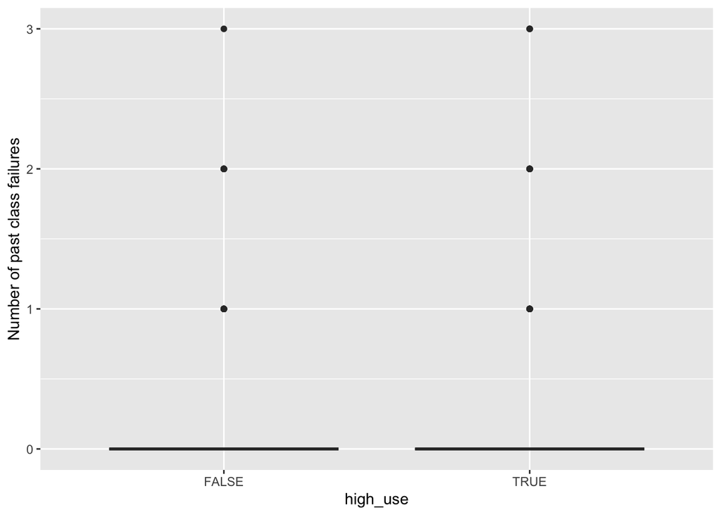

```r
ggplot(alc, aes(x = high_use, y = failures)) +
  geom_boxplot() +
  ylab("Number of past class failures")
```

```r
  ggtitle("Failures by Alchol consumption") +
  theme_minimal()
```

- The distribution of the number of past class failures suggests a difference between students with high and low alcohol consumption. Students with high alcohol consumption tend to have a higher average number of past class failures compared to those with low alcohol consumption.
- But there may not be a clear distinction in the number of past class failures between students with high and low alcohol consumption from the boxplot .

## Logistic regression model

```r
# Fit logistic regression model
lr_mod <- glm(high_use ~ studytime + health + age + failures, data = alc, family = "binomial")

# Summarize the model
summary(lr_mod)
```

```
##
## Call:
## glm(formula = high_use ~ studytime + health + age + failures,
##     family = "binomial", data = alc)
##
## Coefficients:
##             Estimate Std. Error z value Pr(>|z|)
## (Intercept) -3.07479    1.77973  -1.728 0.084047 .
## studytime   -0.54706    0.15908  -3.439 0.000584 ***
## health       0.09449    0.08599   1.099 0.271823
## age          0.17226    0.10359   1.663 0.096339 .
## failures     0.44244    0.20912   2.116 0.034370 *
## ---
## Signif. codes:  0 '***' 0.001 '**' 0.01 '*' 0.05 '.' 0.1 ' ' 1
##
## (Dispersion parameter for binomial family taken to be 1)
##
##     Null deviance: 452.04  on 369  degrees of freedom
## Residual deviance: 423.11  on 365  degrees of freedom
## AIC: 433.11
##
## Number of Fisher Scoring iterations: 4
```

**Coefficients**

Overall, the model suggests that `studytime` and `failures` are significant predictors of high alcohol consumption.

```r
# Extract odds ratios and confidence intervals
OR <- exp(coef(lr_mod))
CI <- exp(confint(lr_mod))
# print out the odds ratios with their confidence intervals
cbind(OR, CI)
```

```
##                     OR       2.5 %    97.5 %
## (Intercept) 0.04619915 0.001352779 1.4736961
## studytime   0.57865033 0.419555718 0.7838258
## health      1.09909517 0.930196868 1.3041181
## age         1.18798337 0.971202684 1.4591156
## failures    1.55649969 1.038624034 2.3726080
```

In summary, the odds ratios provide insights into the direction and magnitude of the relationships between each predictor and the odds of high alcohol consumption. Interpretation of the results involves considering both the point estimates and the confidence intervals. The significant predictors in this model are `studytime` and `failures`, which support *hypothesis 1* and *hypothesis 4*.

## Predictive power of the model

```r
# Fit logistic regression model
lr_mod <- glm(high_use ~ studytime + health + age + failures, data = alc, family = "binomial")

# predict() the probability of high_use
probabilities <- predict(lr_mod, type = "response")

# add the predicted probabilities to 'alc'
alc <- mutate(alc, probability = probabilities)

# use the probabilities to make a prediction of high_use
alc <- mutate(alc, prediction = probability > 0.5)

# see the last ten original classes, predicted probabilities, and class predictions
select(alc, studytime, health, age, failures, high_use, probability, prediction) %>% tail(10)
```

```
## # A tibble: 10 × 7
##    studytime health   age failures high_use probability prediction
##        <dbl>  <dbl> <dbl>    <dbl> <lgl>          <dbl> <lgl>
##  1         2      3    17        0 FALSE          0.277 FALSE
##  2         1      5    19        1 FALSE          0.638 TRUE
##  3         1      3    18        1 TRUE           0.551 TRUE
##  4         3      4    18        0 FALSE          0.225 FALSE
##  5         1      5    18        0 FALSE          0.488 FALSE
##  6         3      5    19        1 FALSE          0.371 FALSE
##  7         2      1    18        0 FALSE          0.274 FALSE
##  8         2      5    18        0 FALSE          0.355 FALSE
##  9         1      2    17        0 TRUE           0.376 FALSE
## 10         1      5    18        0 TRUE           0.488 FALSE
```

```r
# tabulate the target variable versus the predictions
table(high_use = alc$high_use, prediction = alc$prediction)
```

```
##         prediction
## high_use FALSE TRUE
##    FALSE   249   10
##    TRUE     96   15
```

```r
# define a loss function (mean prediction error)
loss_func <- function(class, prob) {
  n_wrong <- abs(class - prob) > 0.5
  mean(n_wrong)
}

# call loss_func to compute the average number of wrong predictions in the (training) data
loss_func(class = alc$high_use, prob = 0)
```

```
## [1] 0.3
```

```r
# change the prob argument to 1
loss_func(class = alc$high_use, prob = 1)
```

```
## [1] 0.7
```

```r
# change the prob argument to prediction probabilities in alc
loss_func(class = alc$high_use, prob = alc$probability)
```

```
## [1] 0.2864865
```

In summary, the model shows decent accuracy.

## 10-fold cross-validation

```r
# compute the average number of wrong predictions in the (training) data
train_error <- loss_func(class = alc$high_use, prob = alc$probability)

# K-fold cross-validation
cv <- cv.glm(data = alc, cost = loss_func, glmfit = lr_mod, K = nrow(alc))

# average number of wrong predictions in the cross validation
cv$delta[1]
```

```
## [1] 0.2918919
```

```r
# 10-fold cross-validation
cv_10fold <- cv.glm(data = alc, cost = loss_func, glmfit = lr_mod, K = 10)
cv_10fold$delta[1]
```

```
## [1] 0.2918919
```

Compared to the model introduced in the Exercise Set (which had about 0.26 error), it seems that my logistic regression model has a slightly higher prediction error.